# Final

### Instructions

**THIS IS AN EXAM:** You need to do it INDEPENDENTLY. You can refer to any materials, but you're NOT allowed to discuss with anyone. You can post questions on Piazza only when you need further clarification.

1) You can use any built-in Python modules for final project. Only the modules that need to be installed in the conda environment need approval.

2) You should run your codes before submission to avoid careless mistakes. PyCharm or other IDEs can help you identify some common errors (IndentationError, SyntaxError, TypeError...).

3) **Due:** 11:59 PM, Dec 18.

4) **Late policy:** a deduction of 10% per day; late submissions will not be accepted after 5 days past the due date.

This final project consists of two parts:

- **Part I: Machine learning**

  **Goal:** Train a machine learning model to predict protein secondary structures.
- **Part II: Website**

  **Goal:** Users can input protein of interest and get the secondary structures predicted by your model trained above.

This is an open-ended question. There is no single best answer. So I'll read through your script and grade it manually. To make your codes more readable, **please make sure your script is well-commented and well-structured** (but don't over-comment your codes; it's unnecessary to comment on every single line of codes). You can check out [here](https://nickmccullum.com/how-to-write-python-comments/) for some tips on how to comment your codes.

**Part I: Machine learning**

1) Please copy the `final` folder from the public directory (`/home/local/CORNELL/public/final`) to your home directory on the teaching server. The folder will be fetched automatically at the time of deadline. DO NOT rename this folder or put it elsewhere (failure to fecth your folder will be regarded as late submission). You don't need to change the permission of the folder as I have sudo access. You don't need to submit anything to Canvas.

2) **Two formats are acceptable.**

- You can create a python script named `final.py` in `final` folder and write your codes in this script.
- I know some of you are using Jupyter Notebook in your local machine or other servers (DO NOT run Jupyter on the teaching server). Since this final project will be graded manually, `final.ipynb` is also acceptable. You can simply upload `final.ipynb` to `final` folder. Actually, I prefer this format as Jupyter has really great markdown function and plots/tables can be displayed right below each cell. But don't worry, what format you use will NOT affect your grades.
- No matter what format you use, you need to keep all codes necessary to run your script. I'll NOT import any modules for you.

3) Filepath issues in `final.py` or `final.ipynb`.

Keep all the files in `final` folder and just use relative file paths (**only filename**) in your codes.

4) More detailed instructions will be provided below.

**Part II: Website**

1) You have created `public_html` and `cgi-bin` folders in the lab session. You should continue to write CGI scripts in `cgi-bin` folder. Please make sure you've set the permission correctly as described in "Lab8.html".

2) Filepath issues in CGI scripts.

You can either use absolute or relative paths. The `public_html` folder will not be fecthed (but I'll check the time stamp of your scripts for late submission). I'll direclty check how your website looks like (http://bscb-teaching.cb.bscb.cornell.edu/~yourNetID/cgi-bin/final.cgi).

3) For Windows users, you may have trouble accessing the website as shown below.

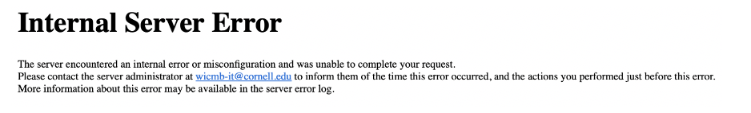

If you're pretty sure you've set the permission correctly and your codes are correct, it's possible that your script has windows line feeds (“\r\n") rather than linux line feeds (“\n”). For more information, you can check out [here](https://stackoverflow.com/questions/12747722/what-is-the-difference-between-a-line-feed-and-a-carriage-return).

To fix this issue, a command line tool `dos2unix` has been installed on the teaching server that can convert files in place if they are created using a windows text editor with windows line endings.

You can simply run `dos2unix <name of CGI file>` in the terminal (make sure you're in the correct directory using `cd` command) to do the conversion, which is pretty fast.

e.g., `dos2unix test.cgi`

4) More detailed instructions will be provided below.

**Please monitor your usage of the computer resources on the teaching server.**

Last year, the teaching server went down several times at the end of semester, as some students forgot to restart the Jupyter notebook which can consume a lot of memory throughout the semester (there could be other unknown reasons). This semester, we don't run Jupyter on the teaching server but there is no gurantee that the server will not crash again. You should pay attention to resource usage by typing `htop` command in the terminal. If you find your script somehow consumes ridiculously high memory, you should kill the process promptly and check why your codes consume such high memory (e.g., an endless loop). For more information, **please refer to "Lab2.html" - "Monitor resource usage in the server".**

If the server crashes, it will cause a lot of trouble as the IT staff who used to maintain this server is on long-term leave. So please take it seriously. This is the last time we use the teaching server this semester. Let's make sure we'll have a happy ending...

### Part I: Machine learning (90pts)

## Background

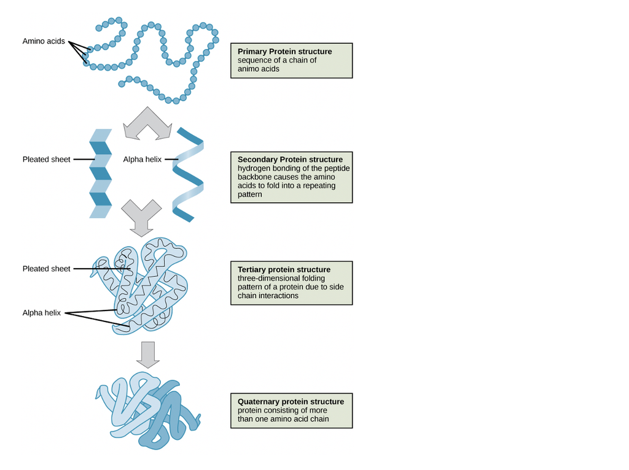

There are four levels of protein structure: primary, secondary, tertiary, and quaternary.

The simplest level of protein structure, **primary structure**, is simply the sequence of amino acids in a polypeptide chain.

The next level of protein structure, **secondary structure**, refers to local folded structures that form within a polypeptide due to interactions between atoms of the backbone. The two most common secondary structural elements are alpha helices and beta sheets, though beta turns and omega loops occur as well.

To make it simpler, you're only required to train a **binary classifier** to predict secondary structure (alpha-helix vs. not alpha-helix) instead of multiclass classifier (alpha helix, beta sheet, omega loop, etc), using features derived from protein sequences (primary structure).

## Dataset

#### `Labels.txt`

This file contains 3 columns:

```
UniProt Position    Label
A0A1C9J6A7  1   0
A0A1C9J6A7  2   0
A0A1C9J6A7  3   0
...
```

- `Uniprot ID`: Uniprot ID for a given protein.
- `Position`: The position of the amino acid (1-based) in a given protein.
- `Label`: `0` indicates that the amino acid in this position has either unknown structure or is known not to form an alpha-helix, while `1` indicates that the position is known to form an alpha-helix.

You can regard each row as a sample, e.g., the label for the first sample (the first amino acid of the protein A0A1C9J6A7) is `0`.

#### `UniProt2Seq.txt`

This file contains 3 columns:

```
UniProt Position    AA
A0R4Q6  1   M
A0R4Q6  2   T
A0R4Q6  3   Q
...
```

- `Uniprot ID`: Uniprot ID for a given protein.
- `Position`: The position of the amino acid (1-based) in a given protein.
- `Amino Acid`: [1-letter abbreviations](https://molbiol-tools.ca/Amino_acid_abbreviations.htm) for amino acids.

The sequence information of all proteins in `Labels.txt` file can be found in `UniProt2Seq.txt` file.

#### `Expasy_AA_Scales.txt`

This file contains 57 predefined [amino acid scales](https://web.expasy.org/protscale/) from the literature. An amino acid scale is defined by a numerical value assigned to each type of amino acid. These scales include hydrophobicity or hydrophilicity scales, the secondary structure conformational parameters scales, and many other scales based on different chemical and physical properties of the amino acids.

- `Amino Acid`: 1-letter abbreviations for amino acids.
- Other columns: each column refers to one amino acid scale.

## Points

This dataset is not easy to classify (most students may get ROC_AUC values around 0.7), but it's not difficult to get basic points for the final project. Since I'll check your codes manually, you can name all variables/functions as whatever you like.

I'll mainly check the following parts:

### Training/test split (5pts)

You'll get full credits as long as you're able to split the dataset into training set and test set in a reasonable way. You can only touch the test set at the end. If you use test set for training, you'll get ZERO points.

### Cross-validation (5pts)

You'll get full credits as long as you're able to do k-fold cross-validation in a reasonable way.

### Feature engineering (20pts)

You may directly use the features from `Expasy_AA_Scales.txt`. You may take into account the sequence context surrounding a given position. For instance, within a 2X-window surrounding a position (pos-X, pos+X), what is the average value on one of the amino acid scales (blurring the feature)? It may also make sense to rank these features to figure out what positions have the highest values relative to the protein they belong in. You may also come up with other informative features.

You need to do some data exploration. Some things you may want to consider...

- How correlated are different features to one another? Can you weed out redundant features?
- How correlated is each feature with the label (e.g., violin plot, boxplot, etc)?
- ...

A rough algorithm for VERY GREEDY (i.e. not optimal) feature selection:

- **Step 1:** Start with an emtpy bag of features.
- **Step 2:** Train your classifier using each of the candidate features alone (or in combination with the current feature bag).
- **Step 3:** Select the single feature that gives the best performance and add it to the feature bag.
- **Step 4:** Repeat steps 2 and 3 until desired number of features are selected or the addition of new features no longer considerably increases performance.
- **Step 5:** Use final selection of features for your final classifier.

You can include a plot that shows how your performance changes with 1 to n features (should be a curve that flattens out at the top).

**Note:** These are just some suggestions. You're NOT required to do all the things mentioned above. You'll get full credits as long as you're able to do feature engineering in a reasonable way and clearly explain why you select what features.

### Model selection (10pts)

There are different machine learning models that can be applied to this problem. You'll get full credits as long as you're able to train at least 3 different models, compare their performance and clearly explain why you select what model.

### Hyperparameter tuning (10pts)

It doesn't have to be comprehensive (i.e., you don't need to test all possible combinations of all hyperparameters). You'll get full credits as long as you're able to demonstrate that you understand how to tune some hyperparameters in a reasonable way.

### Test set 1 (10pts)

Now, you've decided what features to use and successfully trained your final model. You'll get full credits as long as you're able to generate a ROC curve with AUC value and a P-R curve for your test set.

### Test set 2 (20pts)

So far, you've finished the whole process of a machine learning project. It's not difficult to gain all the basic points above.

I'll use a different test set to check the performance of all students's models. Well-trained models deserve more credits.

To do this, you need to wrap up a function (you can name it whatever you like, but make it clear so that I know which function I should use) that I can simply input my test set and get the output - AUC value. My test set is a file in the exact same format as `Labels.txt`（I'll input the whole file, your function should be able to parse the file and get the information you need). The sequence information of all proteins in my test set can also be found in `UniProt2Seq.txt`.

You'll get ZERO points if your function is not working (i.e., I cannot get AUC value for my test set by calling your function).

For students whose function can output AUC value for my test set, I'll rank the values: top 50% can get full credits and the bottom 50% can get partial credits (10pts).

### Thank you (5pts)

You'll get full credits as long as your script is well-commented and well-structured (or at least I can see you've tried your best to do so). Thank you for making my life easier!

### Part II: Website (40pts)

Your task is to design a website to make predictions / display results for a given UniProt ID based on your classifier. You can design your website however you like but should roughly at least have the following functionality and pages...

## Home page (20pts)

You must name this CGI script as `final.cgi` as I'll access your website via http://bscb-teaching.cb.bscb.cornell.edu/~yourNetID/cgi-bin/final.cgi.

#### - Required task (10pts)

The home page should at least provide a text box where users can input UniProt IDs, click a submit button, and be redirected to the corresponding result page. You can decide whether the user can input only one protein or multiple proteins. You need to make it clear on the home page so that the user can know what input format is allowed for your website. Your website may only accept UniProt IDs included in `UniProt2Seq.txt` so that you do not need to fetch any additional sequences.

#### - Optional tasks (10pts)

You can get full credits as long as you can complete one of the following tasks (just pick one you like). Please create a `optional.txt` file in `final` folder and write down which task you pick (brief description of what you've done).

- For proteins not found in `UniProt2Seq.txt`, you may fetch the sequences from other resources by yourself.
- For proteins not found in `UniProt2Seq.txt`, you may allow the user to provide the sequence. For instance, they can upload the fasta file to the website or they can simply copy and paste the sequence in a text box.
- You can make your home page more attractive (this is subjective but I'll not be too picky).

## Result Page (20pts)

You can name this CGI script whatever you like.

#### - Required task (10pts)

Results should be displayed in a tabular format including at least two columns: Position and Prediction. You should be able to show the prediction results (0/1) for all amino acids of the input protein. You can save prediction results for all proteins you have in a file, so that you don't need to recalculate from scratch every time the user input the protein. For new proteins (e.g., you allow the user to provide the sequence not in your database), your website should be able to calculate the features and predict the labels from scratch for those proteins.

#### - Optional tasks (10pts)

You can get full credits as long as you can complete one of the following tasks (just pick one you like). In `optional.txt` file you created above, please write down which task you pick (brief description of what you've done).

- You may add external links to provide additional information about the input protein. For example, the input protein is `Q96NG5`, you can provide a link to UniProt website (e.g., https://www.uniprot.org/uniprot/Q96NG5). It has to be a valid link so that the user can simply click it and be redirected to the corresponding page on UniProt website. It cannot be a text that the user has to copy and paste in a web browser manually.
- You may add `download` buttion so that the user can click the button and download the prediction results of their input proteins (in whatever format you like, e.g., `.csv` file).
- You can make your result page more attractive (this is subjective but I'll not be too picky).